# AIML_Supervised_Learning_Personal_Loan_Campaign

### Thera Bank Personal Loan Campaign

**Data Description:**

The dataset contains data on 5000 customers. The data include customer demographic information (age, income, etc.), the customer's relationship with the bank (mortgage, securities account, etc.), and the customer response to the last personal loan campaign (Personal Loan). Among these 5000 customers, only 480 (= 9.6%) accepted the personal loan that was offered to them in the earlier campaign.

**Domain:** Banking

**Context:** This case is about a bank (Thera Bank) whose management wants to explore ways of converting its liability customers to personal loan customers (while retaining them as depositors). A campaign that the bank ran last year for liability customers showed a healthy conversion rate of over 9% success. This has encouraged the retail marketing department to devise campaigns with better target marketing to increase the success ratio with a minimal budget.

**Attribute Information:**

- ID: Customer ID
- Age: Customer's age in completed years
- Experience: #years of professional experience
- Income: Annual income of the customer($000)
- Personal Loan: Did this customer accept the personal loan offered in the last campaign?
- Securities Account: Doesthe customer have a securities account with the bank?
- CD Account: Doesthe customer have a certificate of deposit (CD) account with the bank?
- Online: Does the customer use internet banking facilities?
- Credit card: Doesthe customer use a credit card issued by the bank?
- ZIP Code: Home Address ZIP code.
- Family: Family size of the customer
- Education: Education Level. 1: Undergrad; 2: Graduate; 3: Advanced/Professional
- Credit Card Avg Spending: Avg spending on credit cards per month
- Mortgage: Value of house mortgage if any

**Learning Outcomes:**

- Exploratory Data Analysis
- Preparing the data to train a model
- Training and making predictions using a classificationmodel
- Model evaluation

**Objective:** The classification goal is to predict the likelihood of a liability customer buying personal loans.

```python
# import the necessary libraries
import numpy as np # linear algebra
import pandas as pd # data processing, CSV file I/O (e.g. pd.read_csv)
import matplotlib.pyplot as plt       # matplotlib.pyplot plots data
%matplotlib inline
import seaborn as sns
```

### Step 1: Load the data set

Import the datasets and libraries, check datatype, statistical summary, shape, null values or incorrect imputation.

```python
# load persomal loan Data
pdata=pd.read_csv("Bank_Personal_Loan_Modelling.csv")
```

```python
print("shape: ", pdata.shape) #print shape
print()
print(pdata.dtypes) #print data types
print()
print("statistical summary: ")
print(pdata.describe())
```

```
shape:  (5000, 14)

ID                      int64
Age                     int64
Experience              int64
Income                  int64
ZIP Code                int64
Family                  int64
CCAvg                 float64
Education               int64
Mortgage                int64
Personal Loan           int64
Securities Account      int64
CD Account              int64
Online                  int64
CreditCard              int64
dtype: object

statistical summary:
                ID          Age   Experience       Income      ZIP Code  \
count  5000.000000  5000.000000  5000.000000  5000.000000   5000.000000
mean   2500.500000    45.338400    20.104600    73.774200  93152.503000
std    1443.520003    11.463166    11.467954    46.033729   2121.852197
min       1.000000    23.000000    -3.000000     8.000000   9307.000000
25%    1250.750000    35.000000    10.000000    39.000000  91911.000000
50%    2500.500000    45.000000    20.000000    64.000000  93437.000000
75%    3750.250000    55.000000    30.000000    98.000000  94608.000000
max    5000.000000    67.000000    43.000000   224.000000  96651.000000

            Family        CCAvg    Education     Mortgage  Personal Loan  \
count  5000.000000  5000.000000  5000.000000  5000.000000    5000.000000
mean      2.396400     1.937938     1.881000    56.498800       0.096000
std       1.147663     1.747659     0.839869   101.713802       0.294621
min       1.000000     0.000000     1.000000     0.000000       0.000000
25%       1.000000     0.700000     1.000000     0.000000       0.000000
50%       2.000000     1.500000     2.000000     0.000000       0.000000
75%       3.000000     2.500000     3.000000   101.000000       0.000000
max       4.000000    10.000000     3.000000   635.000000       1.000000

       Securities Account  CD Account       Online   CreditCard
count         5000.000000  5000.00000  5000.000000  5000.000000
mean             0.104400     0.06040     0.596800     0.294000
std              0.305809     0.23825     0.490589     0.455637
min              0.000000     0.00000     0.000000     0.000000
25%              0.000000     0.00000     0.000000     0.000000
50%              0.000000     0.00000     1.000000     0.000000
75%              0.000000     0.00000     1.000000     1.000000
max              1.000000     1.00000     1.000000     1.000000
```

```python
pdata.head() # print top 5 rows
```

|  | ID | Age | Experience | Income | ZIP Code | Family | CCAvg | Education | Mortgage | Personal Loan | Securities Account | CD Account | Online | CreditCard |
| --- | --- | --- | --- | --- | --- | --- | --- | --- | --- | --- | --- | --- | --- | --- |
| 0 | 1 | 25 | 1 | 49 | 91107 | 4 | 1.6 | 1 | 0 | 0 | 1 | 0 | 0 | 0 |
| 1 | 2 | 45 | 19 | 34 | 90089 | 3 | 1.5 | 1 | 0 | 0 | 1 | 0 | 0 | 0 |
| 2 | 3 | 39 | 15 | 11 | 94720 | 1 | 1.0 | 1 | 0 | 0 | 0 | 0 | 0 | 0 |
| 3 | 4 | 35 | 9 | 100 | 94112 | 1 | 2.7 | 2 | 0 | 0 | 0 | 0 | 0 | 0 |
| 4 | 5 | 35 | 8 | 45 | 91330 | 4 | 1.0 | 2 | 0 | 0 | 0 | 0 | 0 | 1 |

```python
pdata.isnull().values.any() #check for nulls
```

```
False
```

### Step 2: Exploratory Data Analisys

- Number of unique in each column?
- Number of people with zero mortgage?
- Number of people with zero credit card spending per month?
- Value counts of all categorical columns.
- Univariate and Bivariate
- Get data model ready

```python
#number of unique values in each column
print(pdata.nunique())
```

```
ID                    5000
Age                     45
Experience              47
Income                 162
ZIP Code               467
Family                   4
CCAvg                  108
Education                3
Mortgage               347
Personal Loan            2
Securities Account       2
CD Account               2
Online                   2
CreditCard               2
dtype: int64
```

```python
#nummber of people with zero mortgage
people_with_zero_mortgage=pdata[pdata['Mortgage']==0].count()
print("Number of people with zero mortgage: " ,people_with_zero_mortgage['Mortgage'])
```

```
Number of people with zero mortgage:  3462
```

```python
#number of people with zero credit card spending per month
people_with_zero_credit=pdata[pdata['CCAvg']==0].count()
print("Number of people with zero credit card usage: " ,people_with_zero_credit['CCAvg'])
```

```
Number of people with zero credit card usage:  106
```

```python
#value counts of all categorical columns
df_categories=pdata.loc[:,['Securities Account','Personal Loan','CD Account','Online','CreditCard']]
print(df_categories.groupby(['Securities Account']).size())
print(df_categories.groupby(['Personal Loan']).size())
print(df_categories.groupby(['CD Account']).size())
print(df_categories.groupby(['CreditCard']).size())
print(df_categories.groupby(['Online']).size())
```

```
Securities Account
0    4478
1     522
dtype: int64
Personal Loan
0    4520
1     480
dtype: int64
CD Account
0    4698
1     302
dtype: int64
CreditCard
0    3530
1    1470
dtype: int64
Online
0    2016
1    2984
dtype: int64
```

```python
for i in list(df_categories.columns[:]):   # another way to print the value counts
    print(df_categories[i].value_counts())
    print()
```

```
0    4478
1     522
Name: Securities Account, dtype: int64

0    4520
1     480
Name: Personal Loan, dtype: int64

0    4698
1     302
Name: CD Account, dtype: int64

1    2984
0    2016
Name: Online, dtype: int64

0    3530
1    1470
Name: CreditCard, dtype: int64
```

```python
# replace 0=No & 1=Yes for the independant categorical variable
pdata['Securities Account'] = pdata['Securities Account'].replace({1: 'yes', 0: 'no'})
pdata['CD Account'] = pdata['CD Account'].replace({1: 'yes', 0: 'no'})
pdata['Online'] = pdata['Online'].replace({1: 'yes', 0: 'no'})
pdata['CreditCard'] = pdata['CreditCard'].replace({1: 'yes', 0: 'no'})
pdata['Education'] = pdata['Education'].replace({1: 'Undergrad', 2: 'Graduate', 3:'Advanced_Professional'})
print(pdata.dtypes)
# pdata.head()
```

```
ID                      int64
Age                     int64
Experience              int64
Income                  int64
ZIP Code                int64
Family                  int64
CCAvg                 float64
Education              object
Mortgage                int64
Personal Loan           int64
Securities Account     object
CD Account             object
Online                 object
CreditCard             object
dtype: object
```

```python
# get dummy variables for the categorical variables
pdata.drop(columns=['ID'], inplace=True)
pdata=pd.get_dummies(pdata,columns=['Securities Account','CD Account','Online','CreditCard','Education','Family'],drop_first=True)
pdata.head()
```

|  | Age | Experience | Income | ZIP Code | CCAvg | Mortgage | Personal Loan | Securities Account_yes | CD Account_yes | Online_yes | CreditCard_yes | Education_Graduate | Education_Undergrad | Family_2 | Family_3 | Family_4 |
| --- | --- | --- | --- | --- | --- | --- | --- | --- | --- | --- | --- | --- | --- | --- | --- | --- |
| 0 | 25 | 1 | 49 | 91107 | 1.6 | 0 | 0 | 1 | 0 | 0 | 0 | 0 | 1 | 0 | 0 | 1 |
| 1 | 45 | 19 | 34 | 90089 | 1.5 | 0 | 0 | 1 | 0 | 0 | 0 | 0 | 1 | 0 | 1 | 0 |
| 2 | 39 | 15 | 11 | 94720 | 1.0 | 0 | 0 | 0 | 0 | 0 | 0 | 0 | 1 | 0 | 0 | 0 |
| 3 | 35 | 9 | 100 | 94112 | 2.7 | 0 | 0 | 0 | 0 | 0 | 0 | 1 | 0 | 0 | 0 | 0 |
| 4 | 35 | 8 | 45 | 91330 | 1.0 | 0 | 0 | 0 | 0 | 0 | 1 | 1 | 0 | 0 | 0 | 1 |

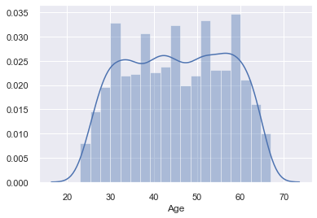

```python
sns.set(color_codes=True) # adds a nice background to the graphs
#univatiant analysis
sns.distplot(pdata['Age'], kde=True)
```

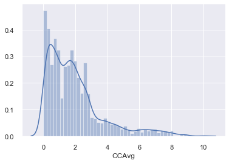

```python
sns.distplot(pdata['CCAvg'], kde=True)
```

```
Age                         int64
Experience                  int64
Income                      int64
ZIP Code                    int64
CCAvg                     float64
Mortgage                    int64
Personal Loan               int64
Securities Account_yes      uint8
CD Account_yes              uint8
Online_yes                  uint8
CreditCard_yes              uint8
Education_Graduate          uint8
Education_Undergrad         uint8
Family_2                    uint8
Family_3                    uint8
Family_4                    uint8
dtype: object
```

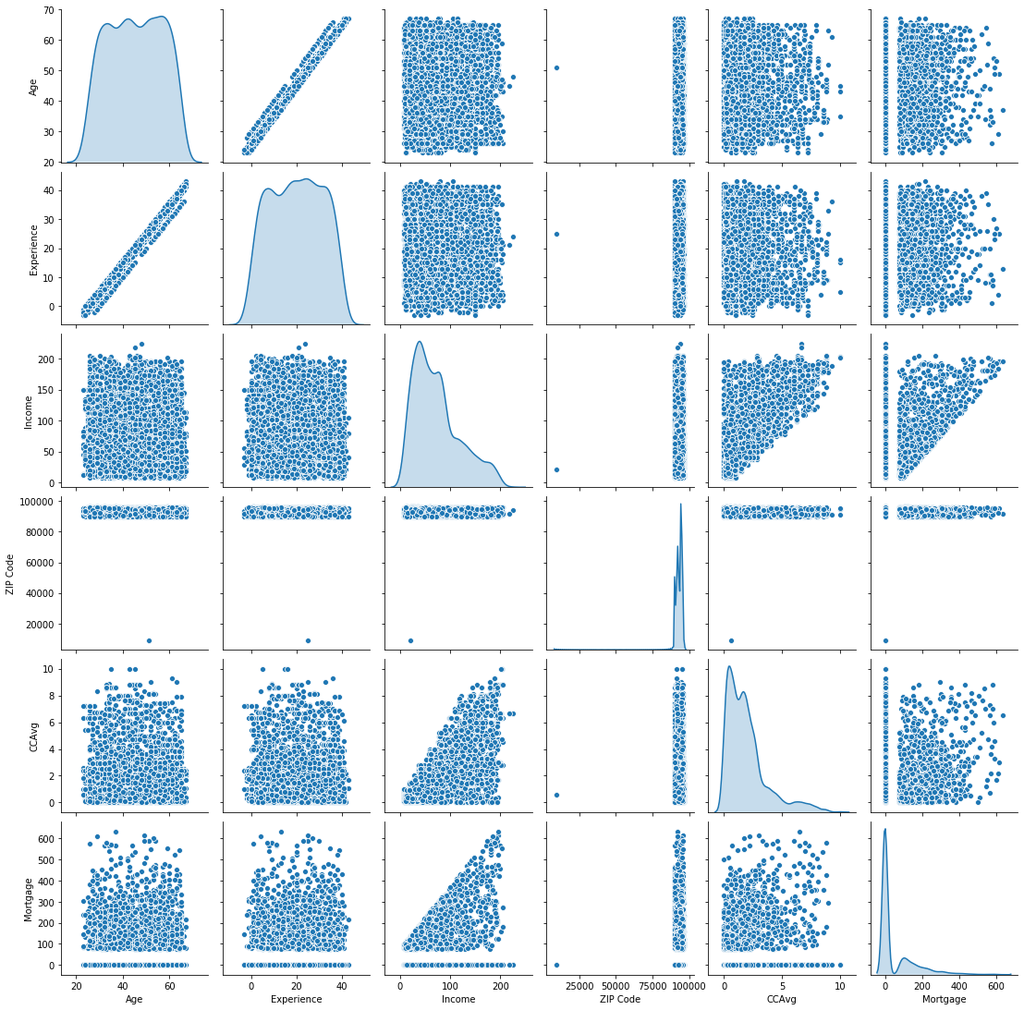

```python
#Bivariate analysis
print(pdata.dtypes)
new_pdata=pdata.iloc[:, 0:6]
sns.pairplot(new_pdata,diag_kind='kde')
```

```python
# Check the correlation in graphical representation so below is function for that
def plot_corr(new_pdata, size=20):
    corr = new_pdata.corr()
    fig, ax = plt.subplots(figsize=(size, size))
    ax.matshow(corr)
    plt.xticks(range(len(corr.columns)), corr.columns)
    plt.yticks(range(len(corr.columns)), corr.columns)
    for (i, j), z in np.ndenumerate(corr):
        ax.text(j, i, '{:0.1f}'.format(z), ha='center', va='center')
```

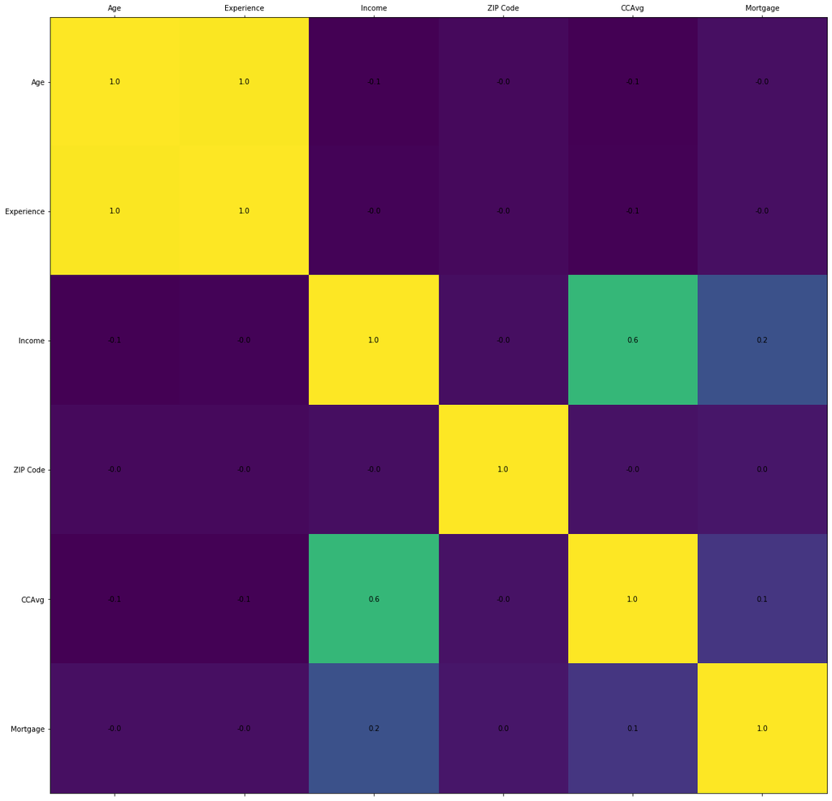

```python
plot_corr(new_pdata)
```

```python
# Get data model ready
#separating dependent and independent variables
X = pdata.drop(['Personal Loan'], axis=1)
Y = pdata.loc[:,['Personal Loan']].astype('category')
print(X.head())
print(Y.head())
```

```
   Age  Experience  Income  ZIP Code  CCAvg  Mortgage  Securities Account_yes  \
0   25           1      49     91107    1.6         0                       1
1   45          19      34     90089    1.5         0                       1
2   39          15      11     94720    1.0         0                       0
3   35           9     100     94112    2.7         0                       0
4   35           8      45     91330    1.0         0                       0

   CD Account_yes  Online_yes  CreditCard_yes  Education_Graduate  \
0               0           0               0                   0
1               0           0               0                   0
2               0           0               0                   0
3               0           0               0                   1
4               0           0               1                   1

   Education_Undergrad  Family_2  Family_3  Family_4
0                    1         0         0         1
1                    1         0         1         0
2                    1         0         0         0
3                    0         0         0         0
4                    0         0         0         1
  Personal Loan
0             0
1             0
2             0
3             0
4             0
```

### Step 3:

Split the data into training and test set in the ratio of 70:30 respectively

```python
from sklearn.model_selection import train_test_split
import statsmodels.api as sm

x_train, x_test, y_train, y_test = train_test_split( X, Y, test_size = 0.3, random_state = 1 )

logit = sm.Logit( y_train, sm.add_constant( x_train ) )
```

```python
x_train.head()
```

|  | Age | Experience | Income | ZIP Code | CCAvg | Mortgage | Securities Account_yes | CD Account_yes | Online_yes | CreditCard_yes | Education_Graduate | Education_Undergrad | Family_2 | Family_3 | Family_4 |
| --- | --- | --- | --- | --- | --- | --- | --- | --- | --- | --- | --- | --- | --- | --- | --- |
| 1334 | 47 | 22 | 35 | 94304 | 1.3 | 0 | 0 | 0 | 1 | 0 | 0 | 1 | 1 | 0 | 0 |
| 4768 | 38 | 14 | 39 | 93118 | 2.0 | 0 | 0 | 0 | 1 | 0 | 1 | 0 | 0 | 0 | 0 |
| 65 | 59 | 35 | 131 | 91360 | 3.8 | 0 | 0 | 0 | 1 | 1 | 0 | 1 | 0 | 0 | 0 |
| 177 | 29 | 3 | 65 | 94132 | 1.8 | 244 | 0 | 0 | 0 | 0 | 1 | 0 | 0 | 0 | 1 |
| 4489 | 39 | 13 | 21 | 95518 | 0.2 | 0 | 0 | 0 | 1 | 0 | 1 | 0 | 0 | 1 | 0 |

```python
print("{0:0.2f}% data is in training set".format((len(x_train)/len(pdata.index)) * 100))
print("{0:0.2f}% data is in test set".format((len(x_test)/len(pdata.index)) * 100))
```

```
70.00% data is in training set
30.00% data is in test set
```

### Step 4: Logistic Regression

Use Logistic Regression model to predict the number of a customers buying personal loans. Print all the metrics related for evaluating the model performance

```python
import warnings
warnings.filterwarnings('ignore')

from sklearn import metrics
from sklearn.metrics import confusion_matrix, recall_score, precision_score, f1_score, roc_auc_score,accuracy_score
from sklearn.linear_model import LogisticRegression

# Fit the model on train
model = LogisticRegression(solver="liblinear")
model.fit(x_train, y_train)
```

```
LogisticRegression(C=1.0, class_weight=None, dual=False, fit_intercept=True,
                   intercept_scaling=1, l1_ratio=None, max_iter=100,
                   multi_class='auto', n_jobs=None, penalty='l2',
                   random_state=None, solver='liblinear', tol=0.0001, verbose=0,
                   warm_start=False)
```

```python
#predict on test
y_predict = model.predict(x_test)

coef_df = pd.DataFrame(model.coef_)
coef_df['intercept'] = model.intercept_
print(coef_df)
```

```
          0         1         2         3         4        5         6  \
0 -0.000564 -0.002681  0.035858 -0.000065  0.012911  0.00085  0.000752

          7         8         9        10        11        12       13  \
0  0.006566 -0.000255 -0.000097  0.007627 -0.015632 -0.005716  0.00627

         14  intercept
0  0.004912  -0.000149
```

```python
## function to get confusion matrix in a proper format
def draw_cm( actual, predicted ):
    cm = confusion_matrix( actual, predicted)
    sns.heatmap(cm, annot=True,  fmt='.2f', xticklabels = [0,1] , yticklabels = [0,1] )
    plt.ylabel('Observed')
    plt.xlabel('Predicted')
    plt.show()
```

```
Trainig accuracy 0.9085714285714286

Testing accuracy 0.9073333333333333

Confusion Matrix
```

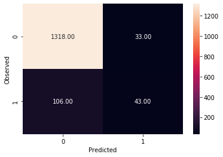

```
None

Recall: 0.28859060402684567

Precision: 0.5657894736842105

F1 Score: 0.38222222222222224

Roc Auc Score: 0.632082126587812
```

```python
print("Trainig accuracy",model.score(x_train,y_train))
print()
print("Testing accuracy",model.score(x_test, y_test))
print()
print('Confusion Matrix')
print(draw_cm(y_test,y_predict))
print()
print("Recall:",recall_score(y_test,y_predict))
print()
print("Precision:",precision_score(y_test,y_predict))
print()
print("F1 Score:",f1_score(y_test,y_predict))
print()
print("Roc Auc Score:",roc_auc_score(y_test,y_predict))

# model_score = model.score(x_test, y_test)
# print(model_score)
```

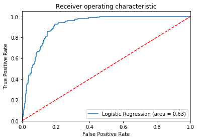

```python
#AUC ROC curve
from sklearn.metrics import roc_auc_score
from sklearn.metrics import roc_curve

logit_roc_auc = roc_auc_score(y_test, model.predict(x_test))
fpr, tpr, thresholds = roc_curve(y_test, model.predict_proba(x_test)[:,1])
plt.figure()
plt.plot(fpr, tpr, label='Logistic Regression (area = %0.2f)' % logit_roc_auc)
plt.plot([0, 1], [0, 1],'r--')
plt.xlim([0.0, 1.0])
plt.ylim([0.0, 1.05])
plt.xlabel('False Positive Rate')
plt.ylabel('True Positive Rate')
plt.title('Receiver operating characteristic')
plt.legend(loc="lower right")
plt.savefig('Log_ROC')
plt.show()
```